# Web-Scrapping Final Project 2020

Extract Flight Data from Expedia Website - Get Back to Budapest

Yuri Almeida Cunha

2020-12-13

# Introduction

On the following project, It was collected flight information from the Brasilia Airport (BSB) to the Rio de Janeiro (GIG/SDU) in order to be able to decide when and what period of the day to buy a specific set of tickets. With that, the project tries verify what is the correlation between the searched flight prices based on the moment of the day and the remaining days until the trip.

# Steps to Collect the Data

## Get to the Website and Define your search terms

Once your done, you will be redirected to the page that contains the amount of dedicated flights by company that operates the following path and destination.

## Retrieve the JSON Link

After selecting the search terms and run the command on the website, a list of flight possibilities will pop up. Open the inspector and check the following URL:

https://www.expedia.com.br/Flight-Search-Paging?c=c475148f-c55d-4539-b37f-db1b8ed1ba20&is=1&sp=asc&cz=200&cn=0

This is the JSON link that contains most of the necessary information regarding the flights. It’s important to take the right one. On the page will find 2 of them, the first one is related to the query parameters used for the search and the second one it’s the one that contains the flight information.

## Add the URL and define the summary parameter

On the webscrapping code there are only two parameters and functions.

### Function

The function is the one that retrieves the entire flight information dataset, where you can visualize the most important information regarding all flights.

### Parameters

The first parameter is the URL, after copying the URL link, you should replace it on the variable SearchString on the code.

PS: Due to a connection limitation it`s important to refresh (copy and paste) the JSON link every 3 hours, you may get disconnected and the following won’t retrieve the necessary information.

```r
SearchString <- "https://www.expedia.com.br/Flight-Search-Paging?c=e15f405f-472d-4c46-a1cf-a3ae5f934e45&is=1&sp=asc&cz=200&cn=0"


# Retrieve_Full_DataSet ---------------------------------------------------


get_flights_table <- function(SearchString){

  df_total = data.frame()

  df_fromJson <- fromJSON(SearchString)

  NestedList <- df_fromJson$content$legs

  previous_data <- read.csv("D:/CEU/Web_Scraping/web_scrapping_yuri/Final_Project/Datasets/flights_table.csv")

  for (i in 1:length(NestedList)){

      t_list <- list()
      t_list[['Fare_Code']] <- NestedList[[i]][['naturalKey']]
      t_list[['Price']] <- NestedList[[i]][['price']][['exactPrice']]
      t_list[['Currency']] <- NestedList[[i]][['price']][['currencyCode']]
      t_list[['AirLineCompany']] <- NestedList[[i]][['carrierSummary']][['airlineName']]
      t_list[['Qtd_Connections']] <- NestedList[[i]][['stops']]
      t_list[['Departure_Airport_City']] <- NestedList[[i]][['departureLocation']][['airportCity']]
      t_list[['Departure_Airport_Code']] <- NestedList[[i]][['departureLocation']][['airportCode']]
      t_list[['Arrival_Airport_City']] <- NestedList[[i]][['arrivalLocation']][['airportCity']]
      t_list[['Arrival_Airport_Code']] <- NestedList[[i]][['arrivalLocation']][['airportCode']]
      t_list[['Departure_Date']] <- NestedList[[i]][['departureTime']][['date']]
      t_list[['Departure_Time']] <- NestedList[[i]][['departureTime']][['time']]
      t_list[['Arrival_Date']] <- NestedList[[i]][['arrivalTime']][['date']]
      t_list[['Arrival_Time']] <- NestedList[[i]][['arrivalTime']][['time']]
      t_list[['Duration_Hours']] <- NestedList[[i]][['duration']][['hours']]
      t_list[['Duration_Minutes']] <- NestedList[[i]][['duration']][['minutes']]
      t_list[['run_time']] <- Sys.time()

    df <- data.frame(t_list)

    df <- separate(data = df, into = c("search_date", "search_time"), col = run_time , sep = ' ')

    df$remaining_days <- as.integer( as.Date(as.character(df$Departure_Date), format="%d/%m/%Y") -
                         as.Date(as.character(df$search_date), format="%Y-%m-%d") )

    df$search_day_period <- with(df, ifelse(hour(hms(search_time)) >= 5 & hour(hms(search_time)) <=11, "morning",
                                        ifelse(hour(hms(search_time))>11 & hour(hms(search_time))<=17, "afternoon", "night")))

    df_total <- rbind(df_total,df)

  }

  flights_df <- dplyr::union(df_total,previous_data)

  write.csv(flights_df, 'D:/CEU/Web_Scraping/web_scrapping_yuri/Final_Project/Datasets/flights_table.csv', row.names = FALSE )

  return(flights_df)

}

flights_df <- get_flights_table(SearchString)
```

# The Datasets

Once you finished running the codes you will end up having the general flights dataset that contains the general information regarding each one of the flights.

What is important to mention is the the fact that the dataset will have columns that define the precise moment when the information was web scrapped, with the exactly period of the day and the remaining days until the flight departure.

Please find the flight dataset example bellow:

| Fare_Code | Price | Currency | AirLineCompany | Qtd_Connections | Departure_Airport_City | Departure_Airport_Code | Arrival_Airport_City | Arrival_Airport_Code | Departure_Date | Departure_Time | Arrival_Date | Arrival_Time | Duration_Hours | Duration_Minutes | search_date | search_time | remaining_days | search_day_period |
| --- | --- | --- | --- | --- | --- | --- | --- | --- | --- | --- | --- | --- | --- | --- | --- | --- | --- | --- |
| 0b247cdb4d777cc15162f54cce0ed2bc | 1748.56 | BRL | LATAM Airlines Group | 1 | Brasília | BSB | Rio de Janeiro | GIG | 28/12/2020 | 11h50 | 28/12/2020 | 19h25 | 7 | 35 | 2020-12-14 | 20:33:07 | 14 | night |
| bd292b97be6669e1ff2362522efa09e6 | 2450.47 | BRL | LATAM Airlines Group | 1 | Brasília | BSB | Rio de Janeiro | SDU | 28/12/2020 | 15h30 | 28/12/2020 | 19h30 | 4 | 0 | 2020-12-14 | 20:33:07 | 14 | night |
| 907a3b0ff35df9491eaf88c9a5d7688d | 2450.47 | BRL | LATAM Airlines Group | 1 | Brasília | BSB | Rio de Janeiro | SDU | 28/12/2020 | 10h25 | 28/12/2020 | 15h10 | 4 | 45 | 2020-12-14 | 20:33:07 | 14 | night |
| 6592c8c1b5f27816f83f4b8d3facc004 | 1306.36 | BRL | GOL Linhas Aereas S.A. | 0 | Brasília | BSB | Rio de Janeiro | SDU | 28/12/2020 | 19h15 | 28/12/2020 | 21h00 | 1 | 45 | 2020-12-14 | 20:33:07 | 14 | night |
| a7bfe5d172c039981a7de03d0fee4e76 | 2450.47 | BRL | LATAM Airlines Group | 2 | Brasília | BSB | Rio de Janeiro | SDU | 28/12/2020 | 11h50 | 28/12/2020 | 19h45 | 7 | 55 | 2020-12-14 | 20:33:07 | 14 | night |
| 95fbaa6db4bca4eb8aa41ddbef53f510 | 1810.16 | BRL | LATAM Airlines Group | 1 | Brasília | BSB | Rio de Janeiro | SDU | 28/12/2020 | 8h55 | 28/12/2020 | 12h50 | 3 | 55 | 2020-12-14 | 20:33:07 | 14 | night |
| 4e5d295393559721a65d8ea48d24be00 | 1810.16 | BRL | LATAM Airlines Group | 1 | Brasília | BSB | Rio de Janeiro | SDU | 28/12/2020 | 12h35 | 28/12/2020 | 19h30 | 6 | 55 | 2020-12-14 | 20:33:07 | 14 | night |
| 85a3d852cf7bd4b53f88ee97c0ed8474 | 2450.47 | BRL | LATAM Airlines Group | 1 | Brasília | BSB | Rio de Janeiro | SDU | 28/12/2020 | 11h00 | 28/12/2020 | 16h40 | 5 | 40 | 2020-12-14 | 20:33:07 | 14 | night |
| 813efcbe26e8e50716a8b67dec5c1955 | 2560.47 | BRL | LATAM Airlines Group | 2 | Brasília | BSB | Rio de Janeiro | SDU | 28/12/2020 | 8h40 | 28/12/2020 | 16h40 | 8 | 0 | 2020-12-14 | 20:33:07 | 14 | night |
| d75521707203dfcaae45a148a5addd52 | 2450.47 | BRL | LATAM Airlines Group | 2 | Brasília | BSB | Rio de Janeiro | SDU | 28/12/2020 | 15h30 | 28/12/2020 | 22h25 | 6 | 55 | 2020-12-14 | 20:33:07 | 14 | night |

# THE ANALYSIS

After retrieving the dataset, it´s time for the analysis. The possible questions are detailed bellow:

Is it better to buy flights during the morning, afternoon or at night? Do the prices change?  
Is there any correlation between the days missing to the flight and their price?

| search_day_period | AirLineCompany | mean | median | std | iq_range | min | max |
| --- | --- | --- | --- | --- | --- | --- | --- |
| afternoon | Azul | 763.7492 | 335.47 | 533.7852 | 929.090 | 335.47 | 1758.46 |
| afternoon | GOL Linhas Aereas S.A. | 1173.9185 | 1207.36 | 424.4281 | 177.100 | 428.47 | 2231.46 |
| afternoon | LATAM Airlines Group | 1997.0947 | 2450.47 | 760.2245 | 640.310 | 286.47 | 2560.47 |
| morning | Azul | 645.1667 | 335.47 | 536.4104 | 464.545 | 335.47 | 1264.56 |
| morning | GOL Linhas Aereas S.A. | 1067.1611 | 1207.36 | 287.8716 | 0.000 | 428.47 | 1207.36 |
| morning | LATAM Airlines Group | 1946.0022 | 2450.47 | 837.9423 | 1013.210 | 428.47 | 2560.47 |
| night | Azul | 1282.6246 | 1758.46 | 670.8259 | 1422.990 | 335.47 | 1758.46 |
| night | GOL Linhas Aereas S.A. | 1408.6213 | 1378.41 | 501.4133 | 468.600 | 428.47 | 2231.46 |
| night | LATAM Airlines Group | 2248.5159 | 2450.47 | 485.5176 | 371.910 | 286.47 | 2560.47 |

| remaining_days | mean | median | std | iq_range | min | max |
| --- | --- | --- | --- | --- | --- | --- |
| 14 | 2257.738 | 2450.470 | 390.9761 | 371.910 | 853.16 | 2560.47 |
| 15 | 1924.436 | 2450.470 | 723.1431 | 1191.135 | 428.47 | 2560.47 |
| 16 | 1518.302 | 1810.160 | 881.9446 | 1947.110 | 286.47 | 2560.47 |
| 17 | 1687.045 | 1810.160 | 737.7887 | 1243.110 | 286.47 | 2560.47 |
| 18 | 1697.561 | 1810.160 | 832.6202 | 1375.110 | 286.47 | 2560.47 |
| 19 | 1542.769 | 1810.160 | 892.0439 | 1947.110 | 335.47 | 2560.47 |
| 20 | 1764.971 | 2450.470 | 873.0377 | 1469.710 | 428.47 | 2560.47 |
| 21 | 1879.241 | 2450.470 | 799.3948 | 1243.110 | 335.47 | 2560.47 |
| 22 | 1853.177 | 2450.470 | 772.3641 | 1243.110 | 286.47 | 2560.47 |
| 23 | 1659.378 | 1810.160 | 820.0453 | 1469.710 | 428.47 | 2560.47 |
| 24 | 1714.172 | 1810.160 | 819.7850 | 1375.110 | 286.47 | 2560.47 |
| 25 | 1853.681 | 2450.470 | 815.5127 | 1298.110 | 286.47 | 2560.47 |
| 26 | 1733.167 | 2340.965 | 863.7920 | 1726.010 | 335.47 | 2560.47 |
| 27 | 1513.592 | 1235.960 | 853.7172 | 1891.835 | 286.47 | 2560.47 |
| 28 | 1591.195 | 1450.460 | 891.7680 | 1947.110 | 335.47 | 2560.47 |
| 29 | 1758.958 | 2450.470 | 857.5931 | 1375.110 | 286.47 | 2560.47 |
| 30 | 1825.661 | 2450.470 | 849.2403 | 1243.110 | 335.47 | 2560.47 |

Now that the summary statistics are done, it’s time to generate the possible correlations (remaining_days ~ min(price), remaining_days ~ mean(price) )

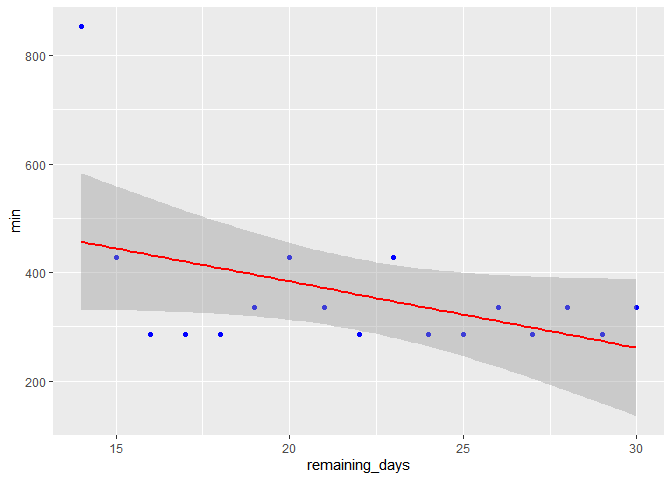

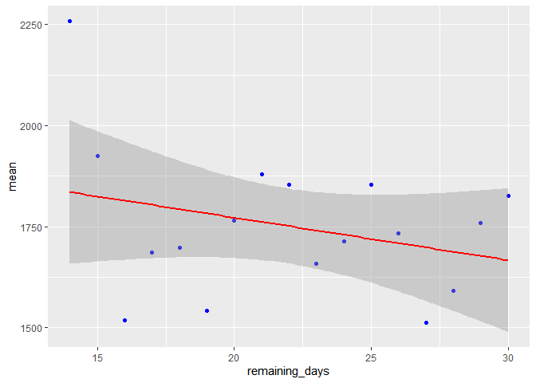

# Conclusion

There wasn’t enough time to retrieve a sufficient amount of data in order to really answer those analytics questions. In order to create the ideas of the graphs, the data was randomly to show the structure about what’s to be evaluated. The project is easy to replicate, you can use different dates and locations, and also and will definitely provide enough information in the future to analyze not only the best ticket buying option, but also how do the air companies regulate their price search data.